# Python Project - (Data from Prosper Loan)

## Introduction

> This data set contains the customer's data from a loan company - **Prosper**. This dataset comprises of 113,937 loans with 81 variables on each loan, including loan amount, borrower rate , current loan status, borrower income, and many others.

```python
## Preliminary Wrangling
```

```python
# import all packages
import numpy as np
import pandas as pd
import seaborn as sns
import matplotlib.pyplot as plt
```

> Load in your dataset and describe its properties through the questions below. Try and motivate your exploration goals through this section.

```python
# load the data set using pandas
loan= pd.read_csv('ProsperLoanData.csv')
loan
```

|  | ListingKey | ListingNumber | ListingCreationDate | CreditGrade | Term | LoanStatus | ClosedDate | BorrowerAPR | BorrowerRate | LenderYield | ... | LP_ServiceFees | LP_CollectionFees | LP_GrossPrincipalLoss | LP_NetPrincipalLoss | LP_NonPrincipalRecoverypayments | PercentFunded | Recommendations | InvestmentFromFriendsCount | InvestmentFromFriendsAmount | Investors |
| --- | --- | --- | --- | --- | --- | --- | --- | --- | --- | --- | --- | --- | --- | --- | --- | --- | --- | --- | --- | --- | --- |
| 0 | 1021339766868145413AB3B | 193129 | 09:29.3 | C | 36 | Completed | 14/08/2009 00:00 | 0.16516 | 0.1580 | 0.1380 | ... | -133.18 | 0.0 | 0.0 | 0.0 | 0.0 | 1.0 | 0 | 0 | 0.0 | 258 |
| 1 | 10273602499503308B223C1 | 1209647 | 28:07.9 | NaN | 36 | Current | NaN | 0.12016 | 0.0920 | 0.0820 | ... | 0.00 | 0.0 | 0.0 | 0.0 | 0.0 | 1.0 | 0 | 0 | 0.0 | 1 |
| 2 | 0EE9337825851032864889A | 81716 | 00:47.1 | HR | 36 | Completed | 17/12/2009 00:00 | 0.28269 | 0.2750 | 0.2400 | ... | -24.20 | 0.0 | 0.0 | 0.0 | 0.0 | 1.0 | 0 | 0 | 0.0 | 41 |
| 3 | 0EF5356002482715299901A | 658116 | 02:35.0 | NaN | 36 | Current | NaN | 0.12528 | 0.0974 | 0.0874 | ... | -108.01 | 0.0 | 0.0 | 0.0 | 0.0 | 1.0 | 0 | 0 | 0.0 | 158 |
| 4 | 0F023589499656230C5E3E2 | 909464 | 38:39.1 | NaN | 36 | Current | NaN | 0.24614 | 0.2085 | 0.1985 | ... | -60.27 | 0.0 | 0.0 | 0.0 | 0.0 | 1.0 | 0 | 0 | 0.0 | 20 |
| ... | ... | ... | ... | ... | ... | ... | ... | ... | ... | ... | ... | ... | ... | ... | ... | ... | ... | ... | ... | ... | ... |
| 113932 | E6D9357655724827169606C | 753087 | 55:02.7 | NaN | 36 | Current | NaN | 0.22354 | 0.1864 | 0.1764 | ... | -75.58 | 0.0 | 0.0 | 0.0 | 0.0 | 1.0 | 0 | 0 | 0.0 | 1 |
| 113933 | E6DB353036033497292EE43 | 537216 | 42:55.3 | NaN | 36 | FinalPaymentInProgress | NaN | 0.13220 | 0.1110 | 0.1010 | ... | -30.05 | 0.0 | 0.0 | 0.0 | 0.0 | 1.0 | 0 | 0 | 0.0 | 22 |
| 113934 | E6E13596170052029692BB1 | 1069178 | 49:12.7 | NaN | 60 | Current | NaN | 0.23984 | 0.2150 | 0.2050 | ... | -16.91 | 0.0 | 0.0 | 0.0 | 0.0 | 1.0 | 0 | 0 | 0.0 | 119 |
| 113935 | E6EB3531504622671970D9E | 539056 | 18:26.6 | NaN | 60 | Completed | 13/08/2013 00:00 | 0.28408 | 0.2605 | 0.2505 | ... | -235.05 | 0.0 | 0.0 | 0.0 | 0.0 | 1.0 | 0 | 0 | 0.0 | 274 |
| 113936 | E6ED3600409833199F711B7 | 1140093 | 27:37.7 | NaN | 36 | Current | NaN | 0.13189 | 0.1039 | 0.0939 | ... | -1.70 | 0.0 | 0.0 | 0.0 | 0.0 | 1.0 | 0 | 0 | 0.0 | 1 |

113937 rows × 81 columns

```python
# load first 10 rows of the data set
loan.head(10)
```

|  | ListingKey | ListingNumber | ListingCreationDate | CreditGrade | Term | LoanStatus | ClosedDate | BorrowerAPR | BorrowerRate | LenderYield | ... | LP_ServiceFees | LP_CollectionFees | LP_GrossPrincipalLoss | LP_NetPrincipalLoss | LP_NonPrincipalRecoverypayments | PercentFunded | Recommendations | InvestmentFromFriendsCount | InvestmentFromFriendsAmount | Investors |
| --- | --- | --- | --- | --- | --- | --- | --- | --- | --- | --- | --- | --- | --- | --- | --- | --- | --- | --- | --- | --- | --- |
| 0 | 1021339766868145413AB3B | 193129 | 09:29.3 | C | 36 | Completed | 14/08/2009 00:00 | 0.16516 | 0.1580 | 0.1380 | ... | -133.18 | 0.0 | 0.0 | 0.0 | 0.0 | 1.0 | 0 | 0 | 0.0 | 258 |
| 1 | 10273602499503308B223C1 | 1209647 | 28:07.9 | NaN | 36 | Current | NaN | 0.12016 | 0.0920 | 0.0820 | ... | 0.00 | 0.0 | 0.0 | 0.0 | 0.0 | 1.0 | 0 | 0 | 0.0 | 1 |
| 2 | 0EE9337825851032864889A | 81716 | 00:47.1 | HR | 36 | Completed | 17/12/2009 00:00 | 0.28269 | 0.2750 | 0.2400 | ... | -24.20 | 0.0 | 0.0 | 0.0 | 0.0 | 1.0 | 0 | 0 | 0.0 | 41 |
| 3 | 0EF5356002482715299901A | 658116 | 02:35.0 | NaN | 36 | Current | NaN | 0.12528 | 0.0974 | 0.0874 | ... | -108.01 | 0.0 | 0.0 | 0.0 | 0.0 | 1.0 | 0 | 0 | 0.0 | 158 |
| 4 | 0F023589499656230C5E3E2 | 909464 | 38:39.1 | NaN | 36 | Current | NaN | 0.24614 | 0.2085 | 0.1985 | ... | -60.27 | 0.0 | 0.0 | 0.0 | 0.0 | 1.0 | 0 | 0 | 0.0 | 20 |
| 5 | 0F05359734824199381F61D | 1074836 | 26:37.1 | NaN | 60 | Current | NaN | 0.15425 | 0.1314 | 0.1214 | ... | -25.33 | 0.0 | 0.0 | 0.0 | 0.0 | 1.0 | 0 | 0 | 0.0 | 1 |
| 6 | 0F0A3576754255009D63151 | 750899 | 52:56.1 | NaN | 36 | Current | NaN | 0.31032 | 0.2712 | 0.2612 | ... | -22.95 | 0.0 | 0.0 | 0.0 | 0.0 | 1.0 | 0 | 0 | 0.0 | 1 |
| 7 | 0F1035772717087366F9EA7 | 768193 | 49:27.5 | NaN | 36 | Current | NaN | 0.23939 | 0.2019 | 0.1919 | ... | -69.21 | 0.0 | 0.0 | 0.0 | 0.0 | 1.0 | 0 | 0 | 0.0 | 1 |
| 8 | 0F043596202561788EA13D5 | 1023355 | 43:39.1 | NaN | 36 | Current | NaN | 0.07620 | 0.0629 | 0.0529 | ... | -16.77 | 0.0 | 0.0 | 0.0 | 0.0 | 1.0 | 0 | 0 | 0.0 | 1 |
| 9 | 0F043596202561788EA13D5 | 1023355 | 43:39.1 | NaN | 36 | Current | NaN | 0.07620 | 0.0629 | 0.0529 | ... | -16.77 | 0.0 | 0.0 | 0.0 | 0.0 | 1.0 | 0 | 0 | 0.0 | 1 |

10 rows × 81 columns

```python
# check to know thw data structure and possible observations\
loan.info()
```

```
<class 'pandas.core.frame.DataFrame'>
RangeIndex: 113937 entries, 0 to 113936
Data columns (total 81 columns):
 #   Column                               Non-Null Count   Dtype
---  ------                               --------------   -----
 0   ListingKey                           113937 non-null  object
 1   ListingNumber                        113937 non-null  int64
 2   ListingCreationDate                  113937 non-null  object
 3   CreditGrade                          28953 non-null   object
 4   Term                                 113937 non-null  int64
 5   LoanStatus                           113937 non-null  object
 6   ClosedDate                           55089 non-null   object
 7   BorrowerAPR                          113912 non-null  float64
 8   BorrowerRate                         113937 non-null  float64
 9   LenderYield                          113937 non-null  float64
```

[output cut: 73 more lines]

```python
# select variables of intrest in the data set
loan= loan.iloc[:, [2,4,5,7,8,9,16,17,18,19,20,21,46,47,48,49,63,67]]
loan.head(5)
```

|  | ListingCreationDate | Term | LoanStatus | BorrowerAPR | BorrowerRate | LenderYield | ListingCategory (numeric) | BorrowerState | Occupation | EmploymentStatus | EmploymentStatusDuration | IsBorrowerHomeowner | DebtToIncomeRatio | IncomeRange | IncomeVerifiable | StatedMonthlyIncome | LoanOriginalAmount | MonthlyLoanPayment |
| --- | --- | --- | --- | --- | --- | --- | --- | --- | --- | --- | --- | --- | --- | --- | --- | --- | --- | --- |
| 0 | 09:29.3 | 36 | Completed | 0.16516 | 0.1580 | 0.1380 | 0 | CO | Other | Self-employed | 2.0 | True | 0.17 | $25,000-49,999 | True | 3083.333333 | 9425 | 330.43 |
| 1 | 28:07.9 | 36 | Current | 0.12016 | 0.0920 | 0.0820 | 2 | CO | Professional | Employed | 44.0 | False | 0.18 | $50,000-74,999 | True | 6125.000000 | 10000 | 318.93 |
| 2 | 00:47.1 | 36 | Completed | 0.28269 | 0.2750 | 0.2400 | 0 | GA | Other | Not available | NaN | False | 0.06 | Not displayed | True | 2083.333333 | 3001 | 123.32 |
| 3 | 02:35.0 | 36 | Current | 0.12528 | 0.0974 | 0.0874 | 16 | GA | Skilled Labor | Employed | 113.0 | True | 0.15 | $25,000-49,999 | True | 2875.000000 | 10000 | 321.45 |
| 4 | 38:39.1 | 36 | Current | 0.24614 | 0.2085 | 0.1985 | 2 | MN | Executive | Employed | 44.0 | True | 0.26 | $100,000+ | True | 9583.333333 | 15000 | 563.97 |

```python
loan.info()
```

```
<class 'pandas.core.frame.DataFrame'>
RangeIndex: 113937 entries, 0 to 113936
Data columns (total 18 columns):
 #   Column                     Non-Null Count   Dtype
---  ------                     --------------   -----
 0   ListingCreationDate        113937 non-null  object
 1   Term                       113937 non-null  int64
 2   LoanStatus                 113937 non-null  object
 3   BorrowerAPR                113912 non-null  float64
 4   BorrowerRate               113937 non-null  float64
 5   LenderYield                113937 non-null  float64
 6   ListingCategory (numeric)  113937 non-null  int64
 7   BorrowerState              108422 non-null  object
 8   Occupation                 110349 non-null  object
 9   EmploymentStatus           111682 non-null  object
 10  EmploymentStatusDuration   106312 non-null  float64
 11  IsBorrowerHomeowner        113937 non-null  bool
 12  DebtToIncomeRatio          105383 non-null  float64
 13  IncomeRange                113937 non-null  object
 14  IncomeVerifiable           113937 non-null  bool
 15  StatedMonthlyIncome        113937 non-null  float64
 16  LoanOriginalAmount         113937 non-null  int64
 17  MonthlyLoanPayment         113937 non-null  float64
dtypes: bool(2), float64(7), int64(3), object(6)
memory usage: 14.1+ MB
```

```python
# Drop missing values
loan= loan.dropna()
loan.info()
```

```
<class 'pandas.core.frame.DataFrame'>
Index: 94844 entries, 0 to 113936
Data columns (total 18 columns):
 #   Column                     Non-Null Count  Dtype
---  ------                     --------------  -----
 0   ListingCreationDate        94844 non-null  object
 1   Term                       94844 non-null  int64
 2   LoanStatus                 94844 non-null  object
 3   BorrowerAPR                94844 non-null  float64
 4   BorrowerRate               94844 non-null  float64
 5   LenderYield                94844 non-null  float64
 6   ListingCategory (numeric)  94844 non-null  int64
 7   BorrowerState              94844 non-null  object
 8   Occupation                 94844 non-null  object
 9   EmploymentStatus           94844 non-null  object
 10  EmploymentStatusDuration   94844 non-null  float64
 11  IsBorrowerHomeowner        94844 non-null  bool
 12  DebtToIncomeRatio          94844 non-null  float64
 13  IncomeRange                94844 non-null  object
 14  IncomeVerifiable           94844 non-null  bool
 15  StatedMonthlyIncome        94844 non-null  float64
 16  LoanOriginalAmount         94844 non-null  int64
 17  MonthlyLoanPayment         94844 non-null  float64
dtypes: bool(2), float64(7), int64(3), object(6)
memory usage: 12.5+ MB
```

### Data cleaning

```python
# Analysis of dataset variables
loan.describe()
```

|  | Term | BorrowerAPR | BorrowerRate | LenderYield | ListingCategory (numeric) | EmploymentStatusDuration | DebtToIncomeRatio | StatedMonthlyIncome | LoanOriginalAmount | MonthlyLoanPayment |
| --- | --- | --- | --- | --- | --- | --- | --- | --- | --- | --- |
| count | 94844.000000 | 94844.000000 | 94844.000000 | 94844.00000 | 94844.000000 | 94844.000000 | 94844.000000 | 94844.000000 | 94844.000000 | 94844.000000 |
| mean | 41.432415 | 0.218182 | 0.191070 | 0.18099 | 2.988254 | 97.880098 | 0.271554 | 5764.908731 | 8746.584992 | 282.738754 |
| std | 10.865313 | 0.080425 | 0.074819 | 0.07459 | 4.097983 | 93.638384 | 0.487438 | 4933.473557 | 6380.759228 | 194.297510 |
| min | 12.000000 | 0.006530 | 0.000000 | -0.01000 | 0.000000 | 0.000000 | 0.000000 | 0.000000 | 1000.000000 | 0.000000 |
| 25% | 36.000000 | 0.155380 | 0.131400 | 0.12140 | 1.000000 | 27.000000 | 0.150000 | 3333.333333 | 4000.000000 | 140.605000 |
| 50% | 36.000000 | 0.208080 | 0.180000 | 0.17000 | 1.000000 | 69.000000 | 0.220000 | 4916.666667 | 7000.000000 | 234.500000 |
| 75% | 36.000000 | 0.283200 | 0.249800 | 0.23950 | 3.000000 | 140.000000 | 0.320000 | 7020.583333 | 13000.000000 | 381.172500 |
| max | 60.000000 | 0.423950 | 0.360000 | 0.34000 | 20.000000 | 755.000000 | 10.010000 | 483333.333300 | 35000.000000 | 2251.510000 |

```python
# convert EmploymentStatusDuration column to an integet data type
loan['EmploymentStatusDuration'] = loan['EmploymentStatusDuration'].astype(int)
loan. info()
```

```
<class 'pandas.core.frame.DataFrame'>
Index: 94844 entries, 0 to 113936
Data columns (total 18 columns):
 #   Column                     Non-Null Count  Dtype
---  ------                     --------------  -----
 0   ListingCreationDate        94844 non-null  object
 1   Term                       94844 non-null  int64
 2   LoanStatus                 94844 non-null  object
 3   BorrowerAPR                94844 non-null  float64
 4   BorrowerRate               94844 non-null  float64
 5   LenderYield                94844 non-null  float64
 6   ListingCategory (numeric)  94844 non-null  int64
 7   BorrowerState              94844 non-null  object
 8   Occupation                 94844 non-null  object
 9   EmploymentStatus           94844 non-null  object
 10  EmploymentStatusDuration   94844 non-null  int32
 11  IsBorrowerHomeowner        94844 non-null  bool
 12  DebtToIncomeRatio          94844 non-null  float64
 13  IncomeRange                94844 non-null  object
 14  IncomeVerifiable           94844 non-null  bool
 15  StatedMonthlyIncome        94844 non-null  float64
 16  LoanOriginalAmount         94844 non-null  int64
 17  MonthlyLoanPayment         94844 non-null  float64
dtypes: bool(2), float64(6), int32(1), int64(3), object(6)
memory usage: 12.1+ MB
```

```python
# rename ListingCategory (numeric)
loan = loan.rename(columns={'ListingCategory (numeric)': 'ListingCategory'})
loan.info()
```

```
<class 'pandas.core.frame.DataFrame'>
Index: 94844 entries, 0 to 113936
Data columns (total 18 columns):
 #   Column                    Non-Null Count  Dtype
---  ------                    --------------  -----
 0   ListingCreationDate       94844 non-null  object
 1   Term                      94844 non-null  int64
 2   LoanStatus                94844 non-null  object
 3   BorrowerAPR               94844 non-null  float64
 4   BorrowerRate              94844 non-null  float64
 5   LenderYield               94844 non-null  float64
 6   ListingCategory           94844 non-null  int64
 7   BorrowerState             94844 non-null  object
 8   Occupation                94844 non-null  object
 9   EmploymentStatus          94844 non-null  object
 10  EmploymentStatusDuration  94844 non-null  int32
 11  IsBorrowerHomeowner       94844 non-null  bool
 12  DebtToIncomeRatio         94844 non-null  float64
 13  IncomeRange               94844 non-null  object
 14  IncomeVerifiable          94844 non-null  bool
 15  StatedMonthlyIncome       94844 non-null  float64
 16  LoanOriginalAmount        94844 non-null  int64
 17  MonthlyLoanPayment        94844 non-null  float64
dtypes: bool(2), float64(6), int32(1), int64(3), object(6)
memory usage: 12.1+ MB
```

```python
# convert ListingCreationDate to datetime datatype
loan['ListingCreationDate'] = pd.to_datetime(loan['ListingCreationDate'], errors='coerce')
loan.info()
```

```
<class 'pandas.core.frame.DataFrame'>
Index: 94844 entries, 0 to 113936
Data columns (total 18 columns):
 #   Column                    Non-Null Count  Dtype
---  ------                    --------------  -----
 0   ListingCreationDate       37919 non-null  datetime64[ns]
 1   Term                      94844 non-null  int64
 2   LoanStatus                94844 non-null  object
 3   BorrowerAPR               94844 non-null  float64
 4   BorrowerRate              94844 non-null  float64
 5   LenderYield               94844 non-null  float64
 6   ListingCategory           94844 non-null  int64
 7   BorrowerState             94844 non-null  object
 8   Occupation                94844 non-null  object
 9   EmploymentStatus          94844 non-null  object
 10  EmploymentStatusDuration  94844 non-null  int32
 11  IsBorrowerHomeowner       94844 non-null  bool
 12  DebtToIncomeRatio         94844 non-null  float64
 13  IncomeRange               94844 non-null  object
 14  IncomeVerifiable          94844 non-null  bool
 15  StatedMonthlyIncome       94844 non-null  float64
 16  LoanOriginalAmount        94844 non-null  int64
 17  MonthlyLoanPayment        94844 non-null  float64
dtypes: bool(2), datetime64[ns](1), float64(6), int32(1), int64(3), object(5)
memory usage: 12.1+ MB
```

```python
# assign ListingCategory to associated attributes
loan['ListingCategory'] = loan['ListingCategory'].map({0:'Not Available', 1:'Debt Consolidation', 2:'Home Improvement', 3:'Business', 4:'Personal Loan', 5:'Student Use', 6:'Auto', 7:'Other', 8:'Baby&Adoption', 9:'Boat', 10: 'Cosmetic Procedure', 11:'Engagement Ring', 12:'Green Loans', 13:'Household Expenses', 14:'Large Purchases', 15:'Medical/Dental', 16:'Motorcycle', 17:'RV', 18:'Taxes', 19:'Vacation', 20:'Wedding Loans'})
loan['ListingCategory'].value_counts()
```

```
ListingCategory
Debt Consolidation    53499
Other                  9431
Not Available          7484
Home Improvement       6917
Business               5192
Auto                   2350
Personal Loan          2259
Household Expenses     1767
Medical/Dental         1382
Large Purchases         795
Taxes                   783
Wedding Loans           729
Vacation                712
Student Use             604
Motorcycle              289
Engagement Ring         201
Baby&Adoption           191
Boat                     83
Cosmetic Procedure       82
RV                       49
Green Loans              45
Name: count, dtype: int64
```

```python
# Convert LoanStatus, ListingCategory, EmploymentStatus, IncomeRange, to category datatype and order the categories
loan['Occupation'] = loan['Occupation'].astype('category')
loan['BorrowerState'] = loan['BorrowerState'].astype('category')
loan['LoanStatus'] = loan['LoanStatus'].astype('category')
loan['ListingCategory'] = loan['ListingCategory'].astype('category')
loan['EmploymentStatus'] = loan['EmploymentStatus'].astype('category')
loan.info()
```

```
<class 'pandas.core.frame.DataFrame'>
Index: 94844 entries, 0 to 113936
Data columns (total 18 columns):
 #   Column                    Non-Null Count  Dtype
---  ------                    --------------  -----
 0   ListingCreationDate       37919 non-null  datetime64[ns]
 1   Term                      94844 non-null  int64
 2   LoanStatus                94844 non-null  category
 3   BorrowerAPR               94844 non-null  float64
 4   BorrowerRate              94844 non-null  float64
 5   LenderYield               94844 non-null  float64
 6   ListingCategory           94844 non-null  category
 7   BorrowerState             94844 non-null  category
 8   Occupation                94844 non-null  category
 9   EmploymentStatus          94844 non-null  category
 10  EmploymentStatusDuration  94844 non-null  int32
 11  IsBorrowerHomeowner       94844 non-null  bool
 12  DebtToIncomeRatio         94844 non-null  float64
 13  IncomeRange               94844 non-null  object
 14  IncomeVerifiable          94844 non-null  bool
 15  StatedMonthlyIncome       94844 non-null  float64
 16  LoanOriginalAmount        94844 non-null  int64
 17  MonthlyLoanPayment        94844 non-null  float64
dtypes: bool(2), category(5), datetime64[ns](1), float64(6), int32(1), int64(2), object(1)
memory usage: 9.0+ MB
```

### What is/are the main feature(s) of interest in your dataset?

The main features of interest from the prosper dataset are - factors that affect a loan's outcome status, factors that could enable a borrower have access to a loan, and ascertaining if EmploymentStatus and Income can facilitate loan request.

### What features in the dataset do you think will help support your investigation into your feature(s) of interest?

The LoanStatus, BorrowerAPR, BorrowerRate, EmploymentStatus,IncomeRange are some of the features in the dataset that will enable me to carry out my analysis. Although, variables like DebtToIncomeRatio and MonthlyLoanPayment will help acertain to ability of borrowers to make installment payment ant intrests on their loans.

## Univariate Exploration

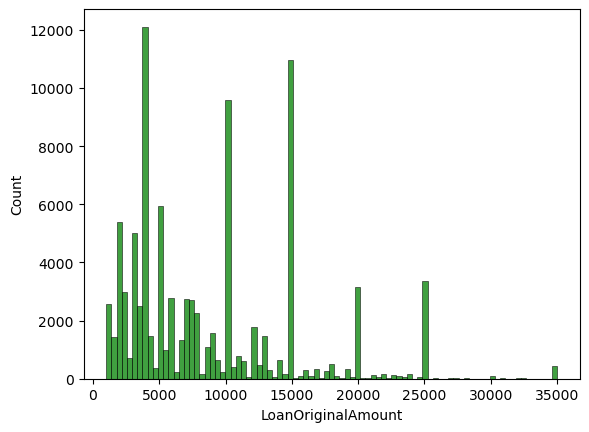

```python
# Create a histogram to show the LoanOriginalAmount distribution
sns.histplot(loan.LoanOriginalAmount,color='green');
```

The distribution for the loan original amount is of a multimodal distribution with various peak variations at different price regions. However, there are outliers at the end of the distributin in the 28000 - 35000 range which depicts that a very low amount of persons where granted huge amount of loans as compared to the lower range of 15000 and below where more loan amount were granted.

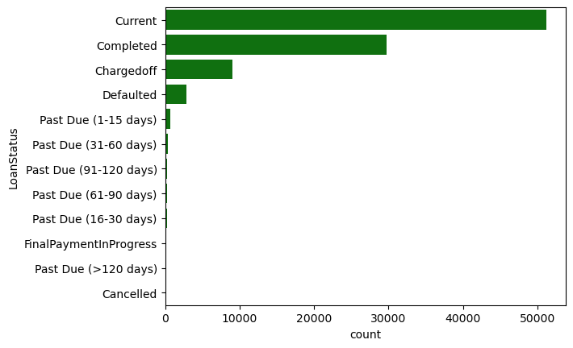

```python
# Create a bar chart for the Loan Status
sns.countplot(data=loan, y='LoanStatus', order=loan.LoanStatus.value_counts().index, color='green');
```

```python
loan.LoanStatus.value_counts()
```

```
LoanStatus
Current                   51170
Completed                 29732
Chargedoff                 9021
Defaulted                  2890
Past Due (1-15 days)        714
Past Due (31-60 days)       322
Past Due (91-120 days)      277
Past Due (61-90 days)       275
Past Due (16-30 days)       241
FinalPaymentInProgress      187
Past Due (>120 days)         14
Cancelled                     1
Name: count, dtype: int64
```

From the above plot, a higher amount of the loans is currently running, while a reasonable amount of the loans is completed.Howerever,proportion of loans have eiter been defaulted or past due the payback period by a number of days

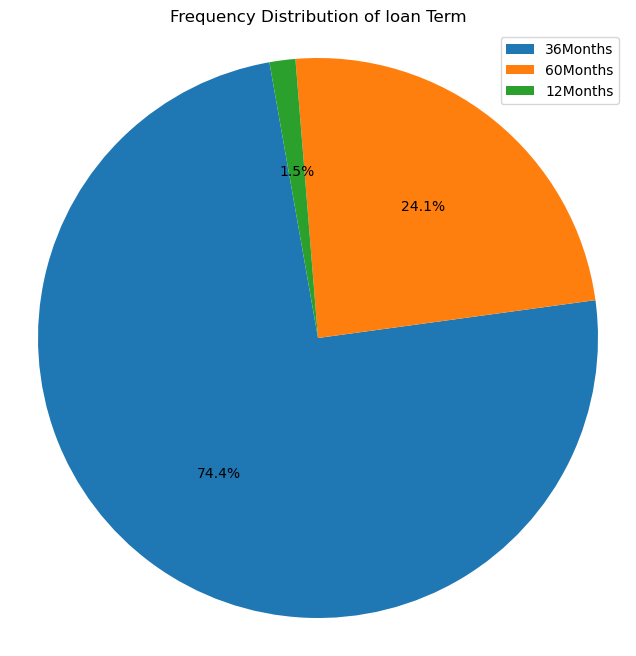

```python
# plot a pie chart for the loan Term
plt.figure(figsize=[8,8])
c = loan.Term.value_counts()
labels = '36Months','60Months','12Months'
plt.pie(c, autopct='%1.1f%%', startangle=100)
plt.title('Frequency Distribution of loan Term')
plt.axis('square')
plt.legend(labels);
```

```python
loan.Term.value_counts()
```

```
Term
36    70546
60    22883
12     1415
Name: count, dtype: int64
```

From the plot above, it can be deduced that a higher proportion of Prosper loans were approved for a 36 months period while a lesser proportion were approved for a 60 month period with a very small proportion of loans approved for a 12 months period.

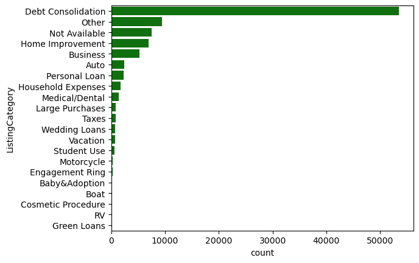

```python
# create a bar chart ordered from the highest count to the lowest from the LIstingCategory
sns.countplot(data=loan, y= 'ListingCategory', order=loan.ListingCategory.value_counts().index, color='green',);
```

```python
loan.ListingCategory.value_counts()
```

```
ListingCategory
Debt Consolidation    53499
Other                  9431
Not Available          7484
Home Improvement       6917
Business               5192
Auto                   2350
Personal Loan          2259
Household Expenses     1767
Medical/Dental         1382
Large Purchases         795
Taxes                   783
Wedding Loans           729
Vacation                712
Student Use             604
Motorcycle              289
Engagement Ring         201
Baby&Adoption           191
Boat                     83
Cosmetic Procedure       82
RV                       49
Green Loans              45
Name: count, dtype: int64
```

From the ListCategory, the distribution of Debt Consolidation is the most listing or better still the most reason for loans applied for at Prosper with Green Loans showing as the least reason for a loan application.

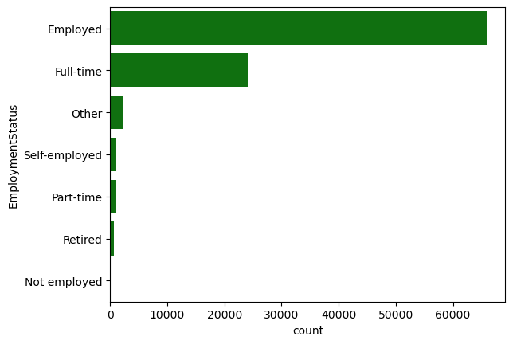

```python
# Create a bar chart using barchart function for EmploymentStatus
sns.countplot(data=loan, y='EmploymentStatus', order=loan.EmploymentStatus.value_counts().index, color= 'green');
```

As expected, employed persons would get loans over those not employed, retired, working part-time and other forms of employment without a fixed income. This is self evident as seen in the chart of Employment status above.

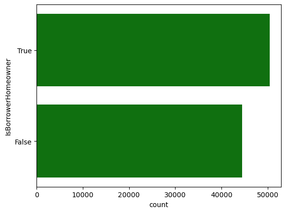

```python
# create a bar chart for IsBorrowerHomeowner
sns.countplot(data=loan, y='IsBorrowerHomeowner', order=loan.IsBorrowerHomeowner.value_counts().index, color= 'green');
```

The chart above shows that being a home owner does not play a fundametal role in obtaining a loan from Prosper loans.

## Bivariate Exploration

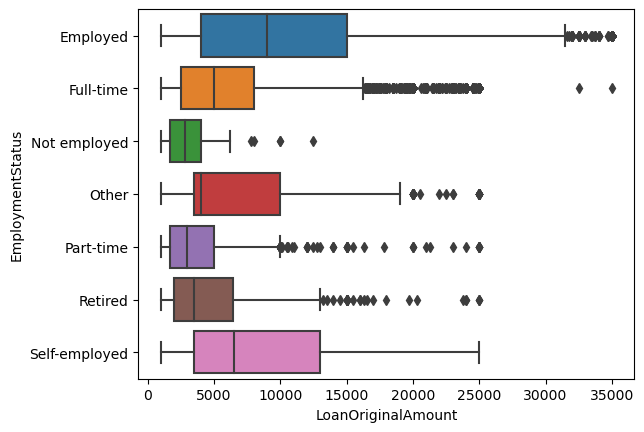

```
(None,)
```

```python
#  reating a boxplot to show if there is a relationship between LoanOriginatAmount and EmploymentStatus
sns.boxplot(data=loan, x='LoanOriginalAmount', y='EmploymentStatus');
plt.show(),
```

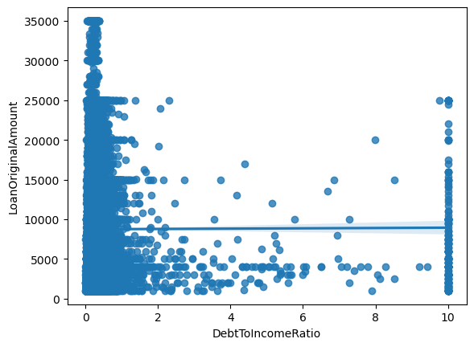

```python
# Relationship between DebtToIncome to LoanOriginalAmount
sns.regplot(data= loan, x='DebtToIncomeRatio', y='LoanOriginalAmount');
```

in the scatter plot above, there is no correletion between the LoanOriginalAmount and DebtToIncomeRatio, hence a horizontal line.

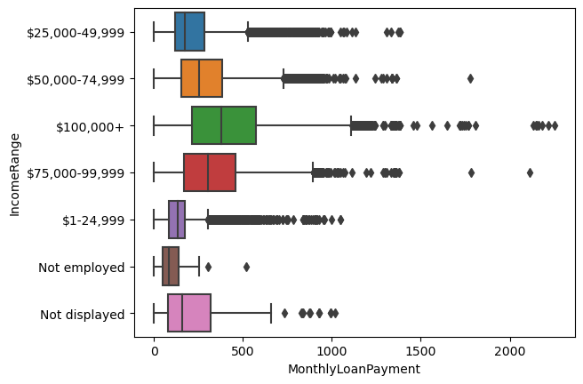

```python
# monthlyLoanPayment and IncomeRange
sns.boxplot(data=loan, x='MonthlyLoanPayment', y='IncomeRange');
```

From the plot above, those earning 100000 and above make the most monthly repayment loan plan. it shows the higher the borrower earn, the more repayment borrower's remit.

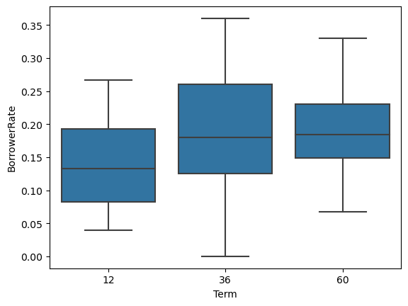

```python
# correlation between BorroersRate and loan Term
sns.boxplot(data=loan,  y='BorrowerRate', x='Term',color=sns.color_palette()[0]);
```

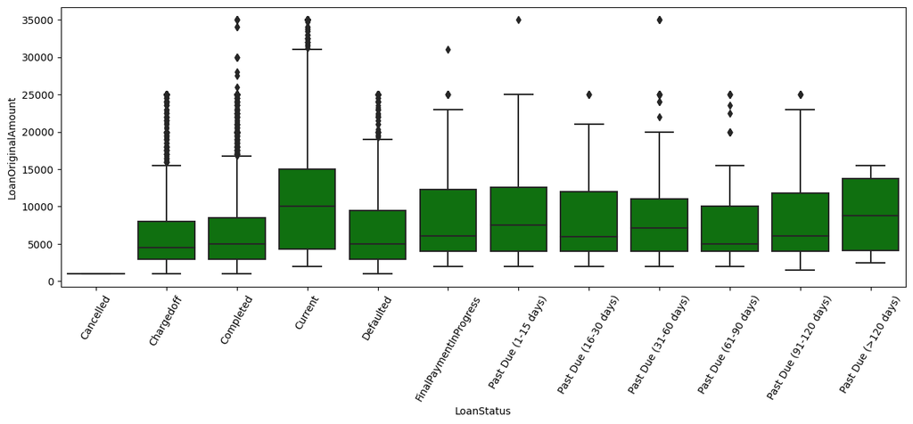

```python
#Creating a clustered bar chart to show the relationship btw loan status vs Loan Original amount
plt.figure(figsize=[15,5])
sns.boxplot(data=loan, x='LoanStatus', y='LoanOriginalAmount', color='green') #box plot using seaborn
plt.xticks(rotation=60); #rotate x labels by 90deg.
```

Only current loan statuses stood out as the category that had access to higher sizes of loans. Thus we can safely say that the loan original amount did not have any significant effect on the loan statuses of borrowers. Those that defaulted and those that their due repayment has elapsed also had access to sizeable portion of the loans in prosper.

### Talk about some of the relationships you observed in this part of the investigation. How did the feature(s) of interest vary with other features in the dataset?

From the charts from Prosper loans, we can observed that from Loan original amount 28000-35000 range very low amount of persons where granted huge amount of loans as compared to majority obtaining loans from 15000 and below.

Also,from the loan status, a higher amount of the loans is currently running, while a propotion of person have defaulted and a few have passed their due data.

Majority of the loans term have a 36 months lenght making 74.4% of the entire loan. while the remaining of the loan terms has a lenght of 60 and 12 months respectively compraising 24.1% and 1.5% of the loan term.

## Conclusions

The loan dataset from Prosper loans had a large amount variables(81), but for the purpose of analysis eighteen(18) variables was selected. data wrangling and manupulation was done to prepare the data for analysis.

The main question that guided the exploration and analysis of the loan dataset are as follows: a. What factors enable one to obtain loan b. The reason people obtained laons from Prosper c. Is there a nexus between Loan status, Loan original amount and term.

a. From the charts, being employed and having a full time job is a major criteria for obtaining loans from prosper

b. Obviously,from the plot, the main reason people obtain loans is simply for debt consolidation i.e people borrowring loans to pay off several existing debts.